# Covid 19 and Traffic

Last updated: 18.12.2020

### Introduction

Following the guidelines to stay at home as much as possible during the pandemic, the number of people working from their homes have increased dramatically throughout the year. In Norway, road traffic data is very easy to obtain from Vegvesenet. This makes it possible to look at traffic data to see how road traffic has been affected by the virus.

The data used in this document comes from 161 traffic measuring stations located in Tromsø, Bergen and Oslo, and is used to showcase how 2020 differs from previous years. All measuring stations are in urban locations, so all any graphs will be based on urban car traffic.

### Smaler cars

Each of the measuring stations count the amount of cars that passes by them. The data set used here contains the amount of cars that pass by each sensor per month. The amount of cars passing by the different sensors is then averaged to produce a monthly average of cars per sensor. This average is what will be used to measure traffic in the graphs bellow.

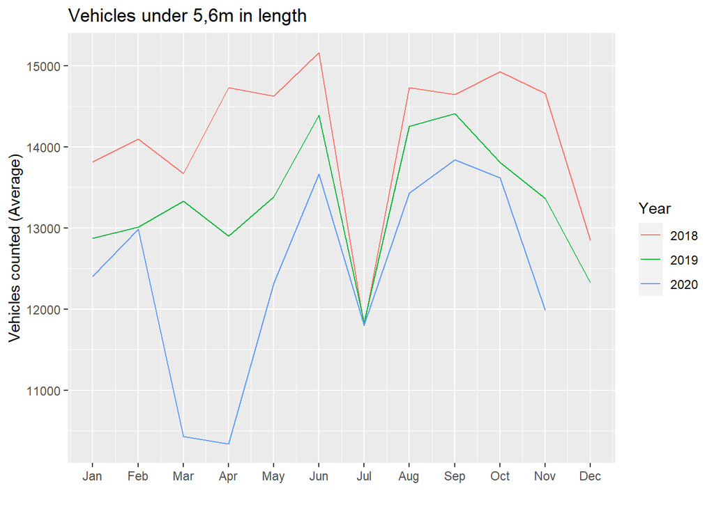

Looking at the data for passenger cars, a clear decrease in traffic can be seen during the months of the initial wave. Traffic seems to return to normal after the initial wave.

### Other vehicle groups

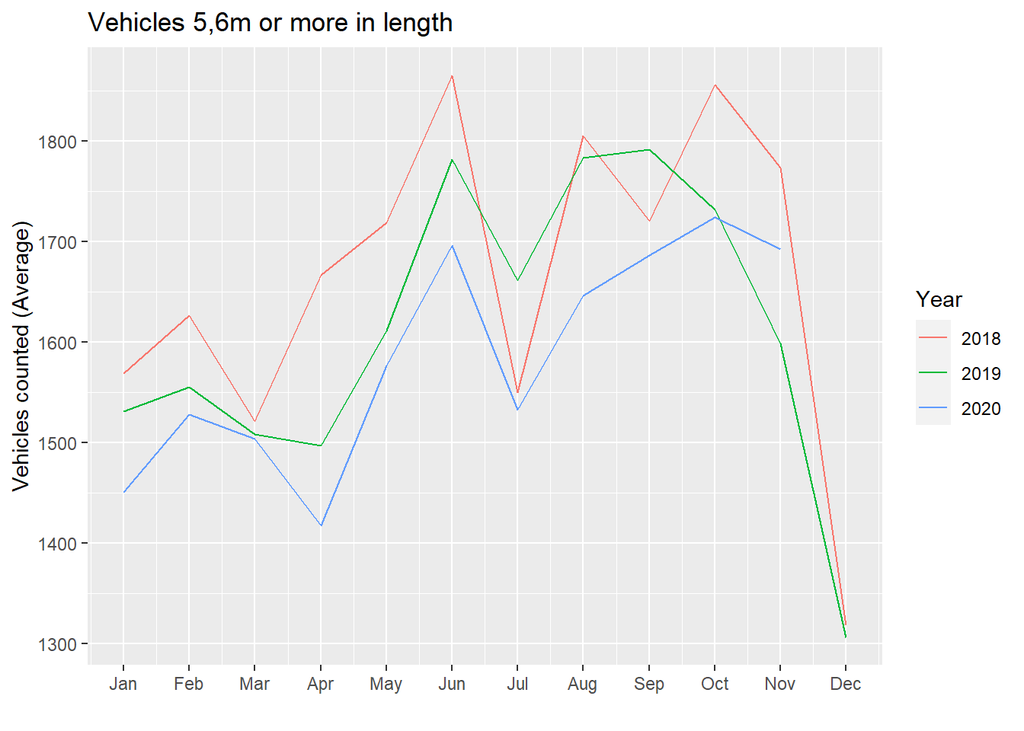

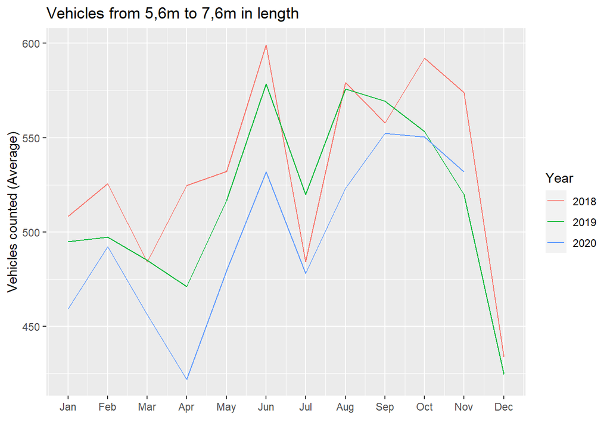

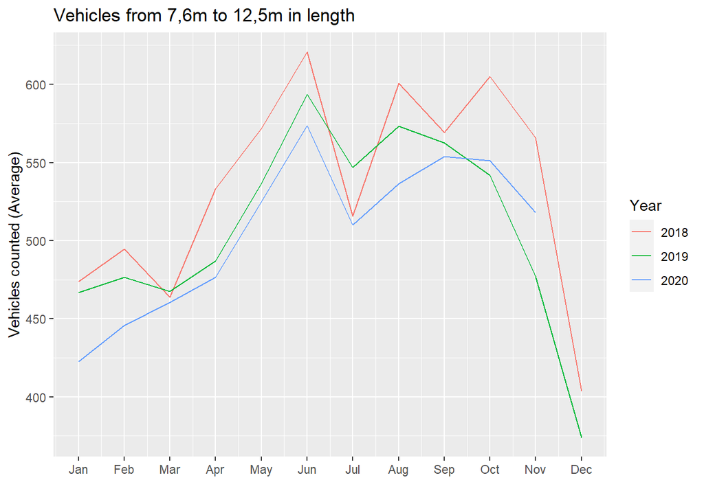

### 12,5-16m

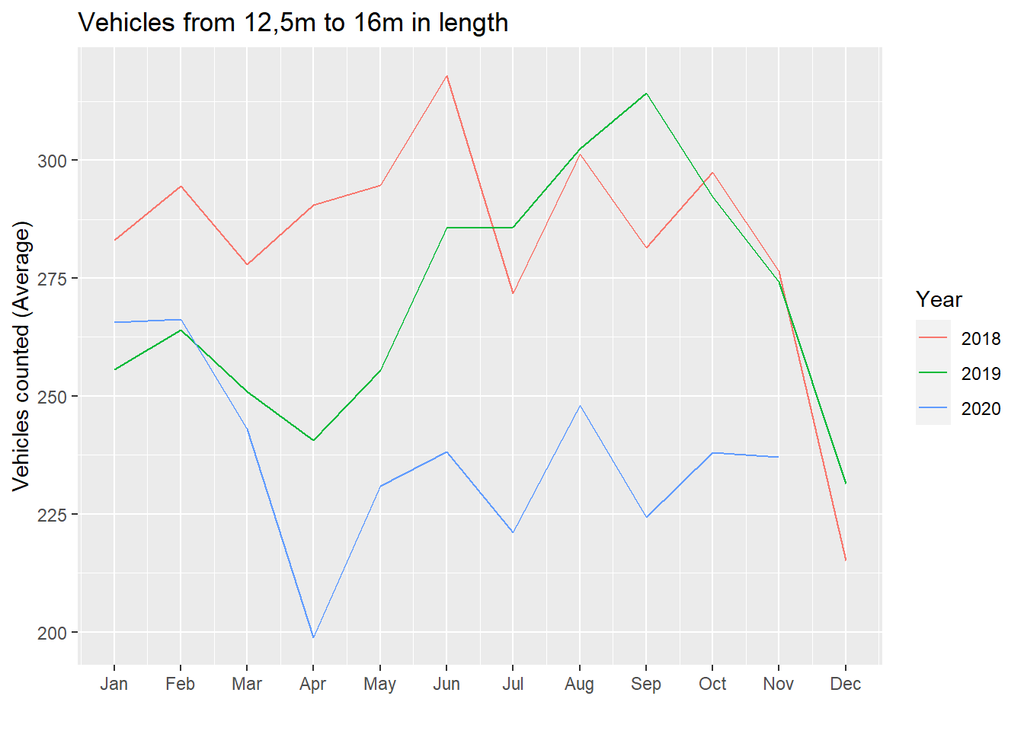

Vehicles length 12,5-16m can be seen experiencing the same dip in April as smaller cars, however they do no return to normal after the first wave. While their usage increases a bit after the wave, the amount of vehicles this size seems to be noticeably reduced throughout the rest of the year. Additionally, as a fun little tidbit, the line representing their usage in 2019 is the only line in any of the graphs so far not to have a dip in July.

### Vehicles length 16m and up

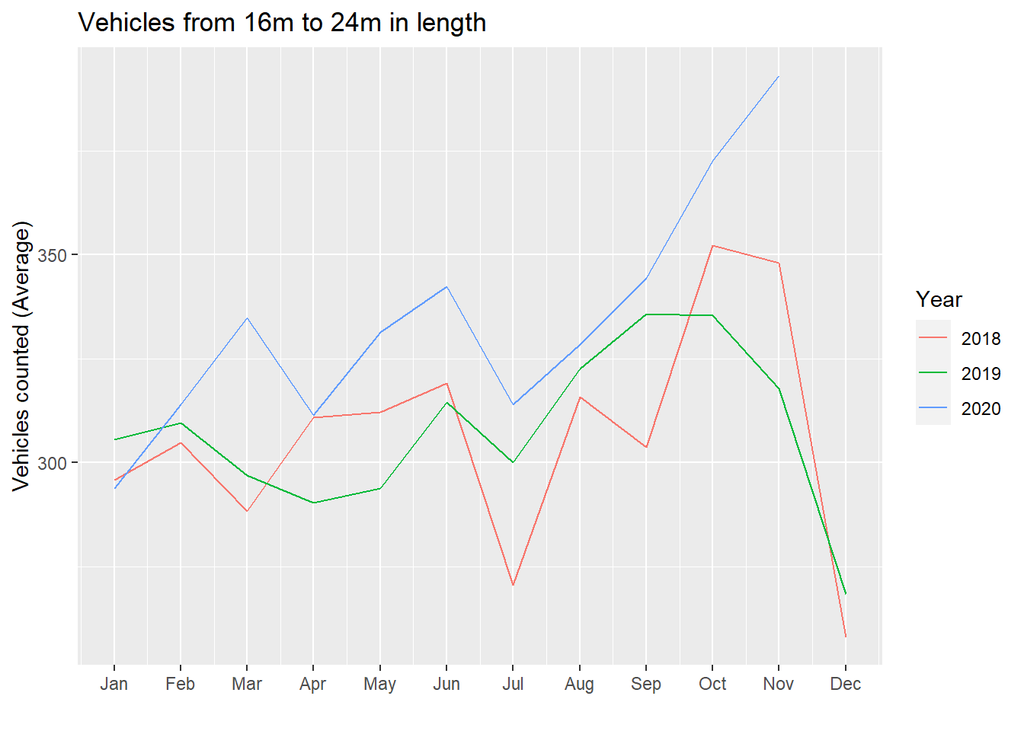

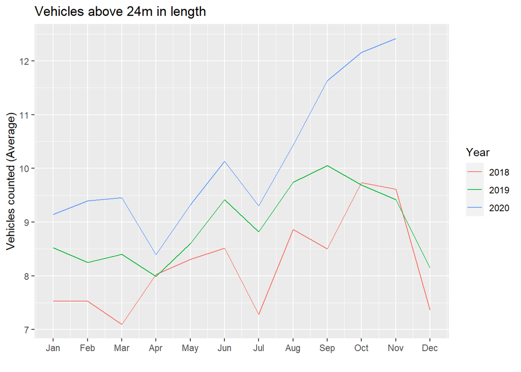

Large vehicles see a large increase towards the end of the year, likely due to an increase in online shopping. The increase in packages ordered has been written about by several media outlets, as it has led to multiple stores and post offices being overwhelmed with packages to be picked up.

### Graphing changes in traffic

One ting the graphs so far has shown, is that traffic is changing slightly year by year. To better visualize the impact covid has had on traffic this year, it is important to compare that impact to the changes normally seen in traffic.

The following graph compares the traffic data for a given month, and compares it to the same month the previous year. The total difference, positive or negative, is then used to plot the difference in average traffic rates. The graph that is produced visualizes where a year is different to the year previous, and how big that difference is.

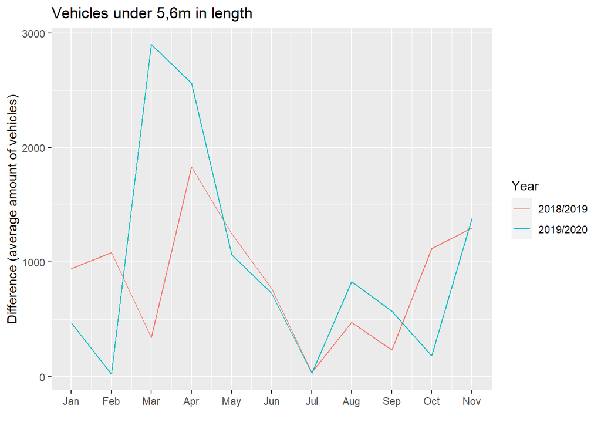

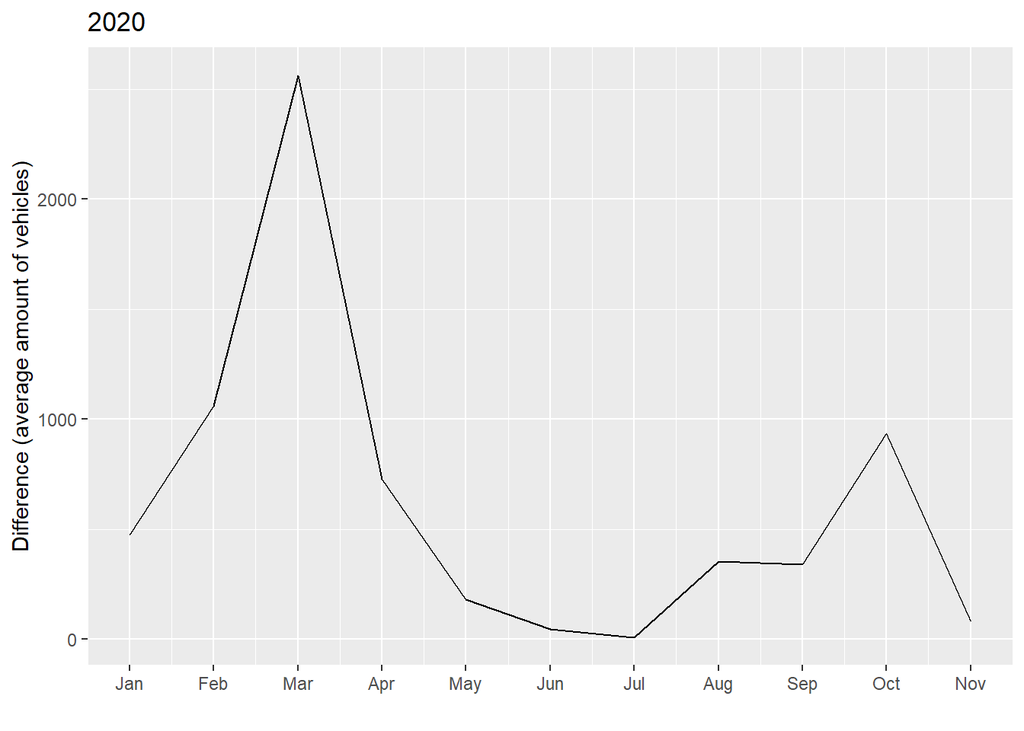

We can see that there are large differences between 2020 and 2019, even compared to the normal amount of change from one year to another.

### Large Vehicles

Creating similar graphs for vehicles sizes 16m or longer clearly visualizes the increase of these vehicles towards the later months of the year.

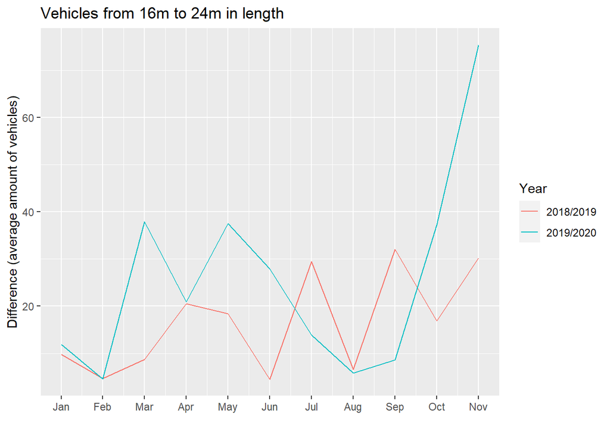

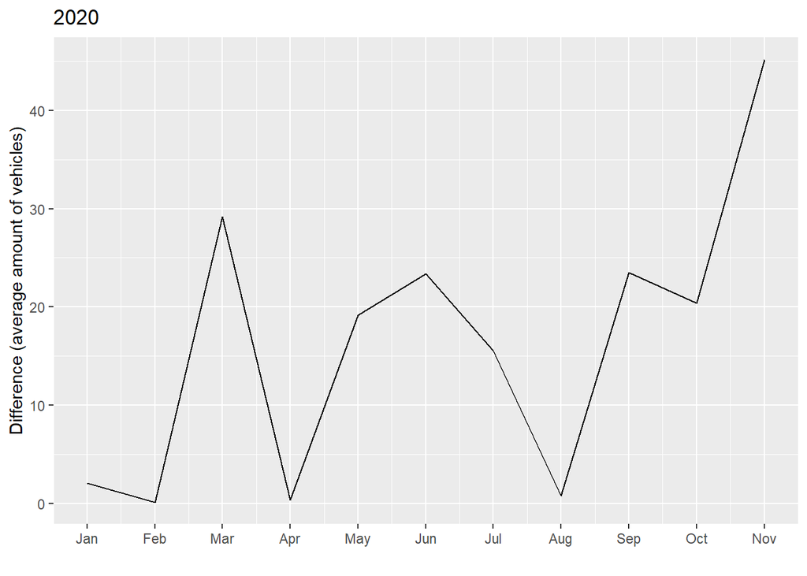

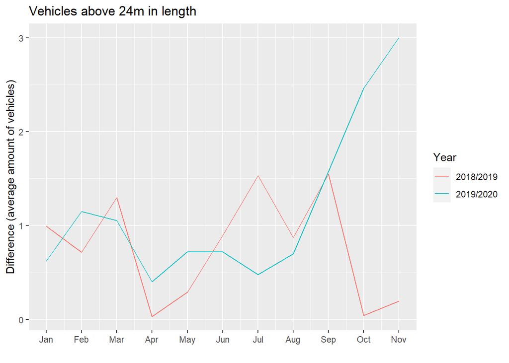

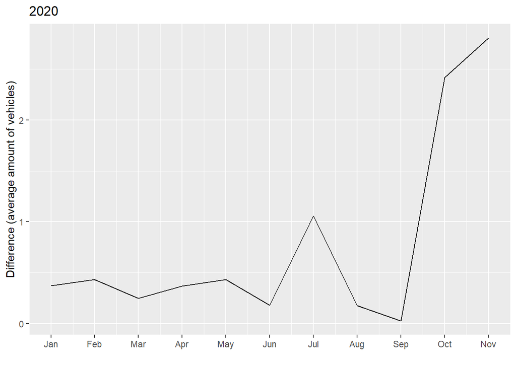

### Compared to first graph

The “difference graphs” from above shows the hot-spots where traffic from 2020 differ from previous years

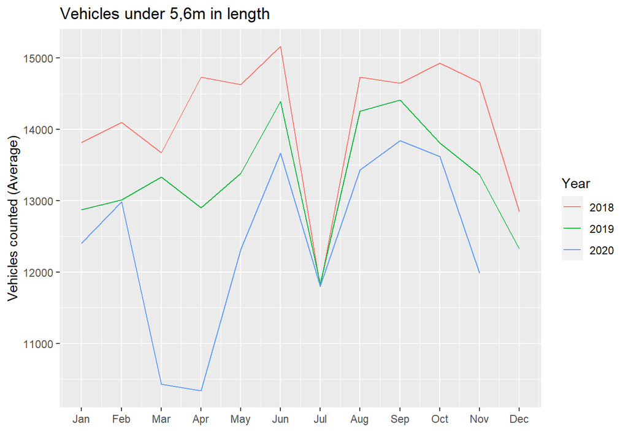

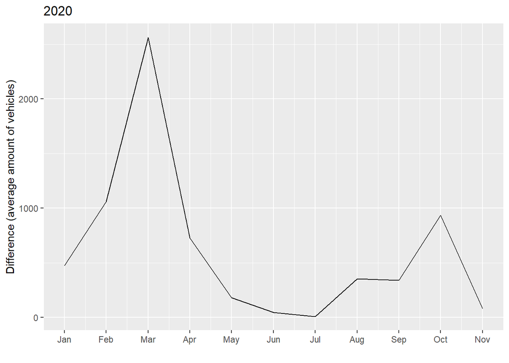

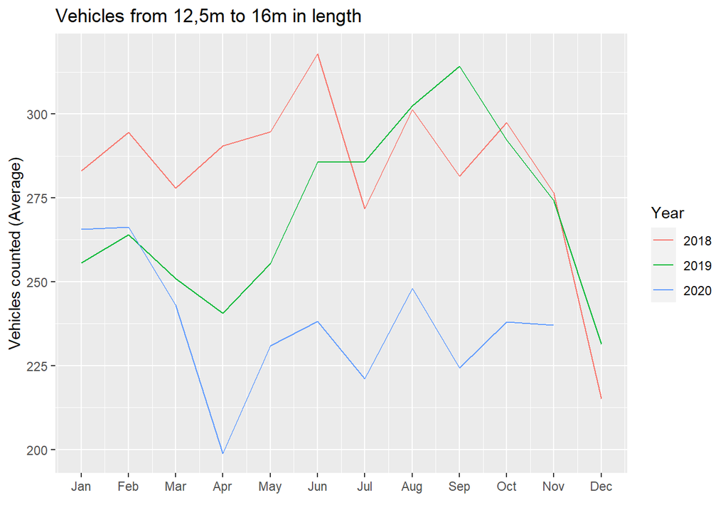

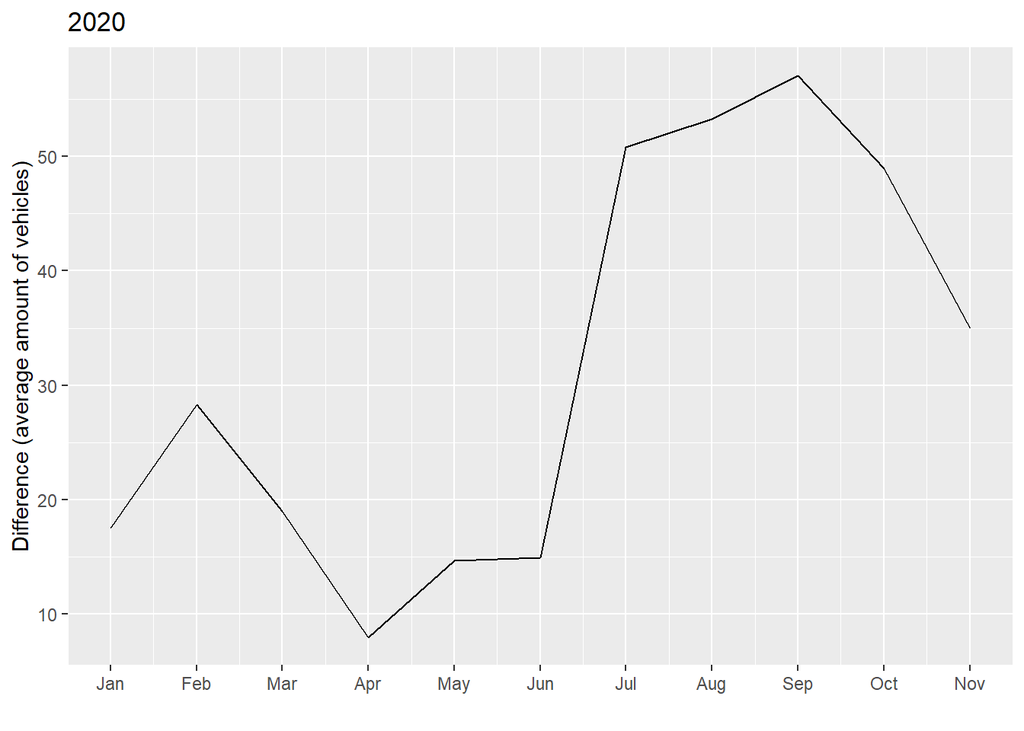

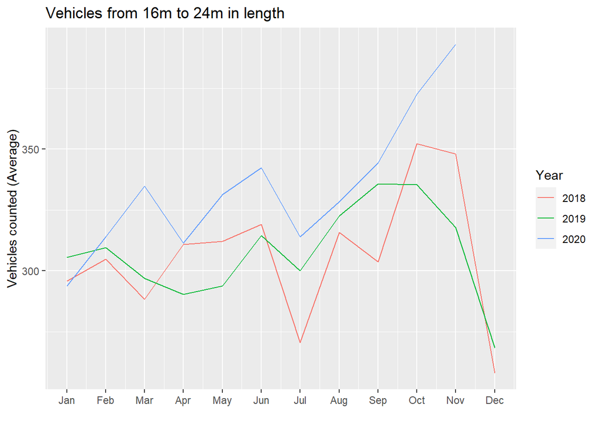

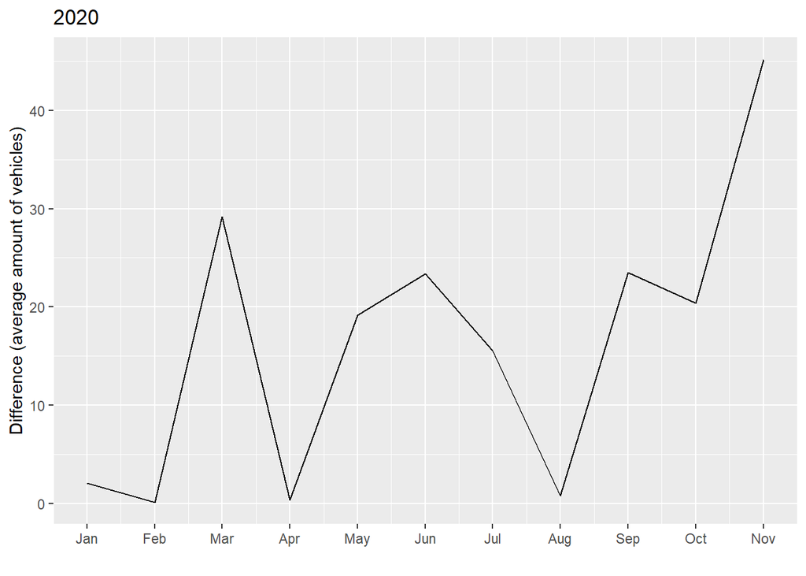

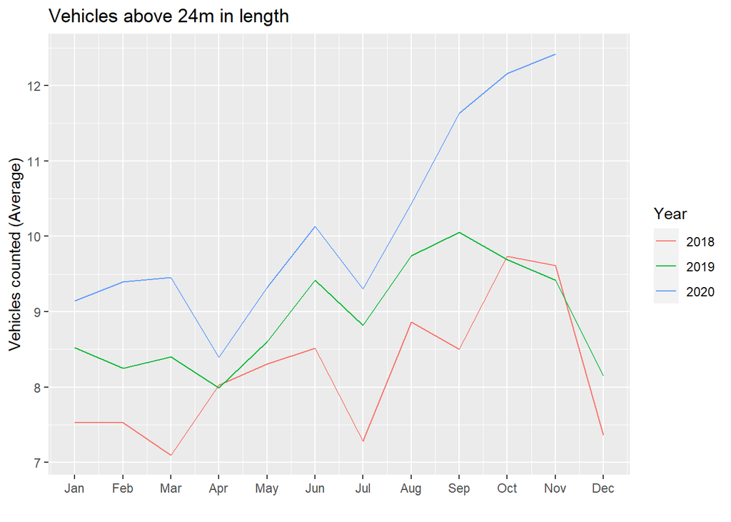

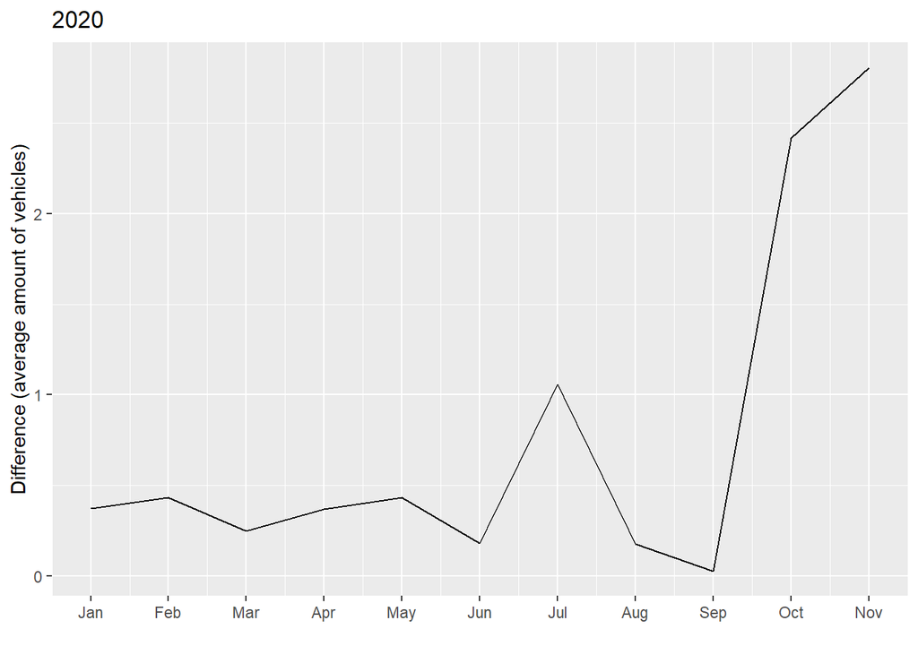

Looking at the above graphs, it is clear that covid has had a significant impact on urban car traffic, especially in March and towards the end of the year.

Data Source: https://www.vegvesen.no/trafikkdata